# Income and Disability Maps in California

Chandrima Chatterjee | Tanya Chen | Rya Jasin Donelo

## Introduction

The dataset person_house_map and travel_map included information on individuals. In person_house_map there is information on demographics, whether the individual has a disability and what kind, how much their incomes are, whether it is household income, personal income, etc, whether they’re employed, and finally whether they recieve ssi. In travel_map they include some of this same information but also include what type of support they need for travelling, whether they can drive, how many different modes of transportation they’ve used, and average distance travelled. Finally the disability statistics annual report outlined how people with disabilities generally are worser off than people without [^1]. Looking at these datasets and the report we decided that our question would be “How does disability affect an individual’s economic situation and how does it relate to the proportion of disabled people within each county in California?”

## Population Density and Number of Disabled People Present in CA

This interactive map depicts information on the population within each county in California, as well as how many disabled people are present within each of those counties. Darker colors correlate to a higher the population. From this the viewer can discern the general proportion of disabled people within each county. For example Los Angeles County has a population between 10,000,000-11,000,000 and the data says it has a disabled population of 129. In other counties the proportion is higher/lower. This map may help people see the importance of taking strides towards accessibility given how large the proportion of disabled people within each county is.

[interactive chart not shown]

## Average Personal Annual Income Distribution of People with or without Disability in CA

The static map shows the average personal annual income distribution in CA. The distribution is facet by whether people have any disability or not. According to map, the mean personal annual income for people with disability in CA is mostly lower than that of people without disability. The range of mean personal annual income for people with disability is between 0 to 66,666.667. Most counties’ average annual income for disabled people is between 0 to 35,000. For people without disability, the range of average annual income is between 20,232.578 to 113,372.455. Most counties’ average annual income is between 30,000 to 60,000. The mean annual income for people without disability is two times more than that for people with disability.

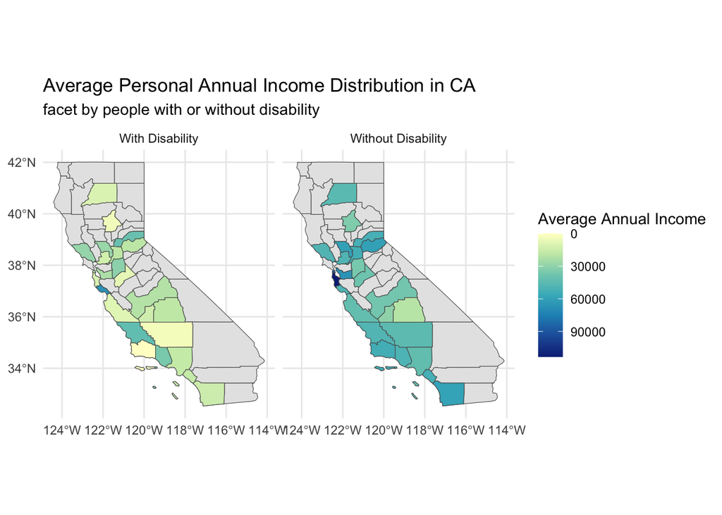

## Difference in Total Household Income for People who receive SSI or not in CA

This static map aims to see a difference in the total household income among those people who have disability and have less than $50,000 total household income and if they receive SSI or not in the counties of California. In the maps, it is evident that those who receive SSI have less household income. There is less darker shade seen in the map. On the other hand, those who do not receive SSI, they have higher total household income. In this map, there are more darker shades indicating higher income. In addition, comparing the two maps, there is no county in the ones that receive SSI that might have a household income between 45000 to 50000. From this, we can deduce that since those people who have lower household income, they receive SSI since they need assistance for their daily living and for their household expenses.

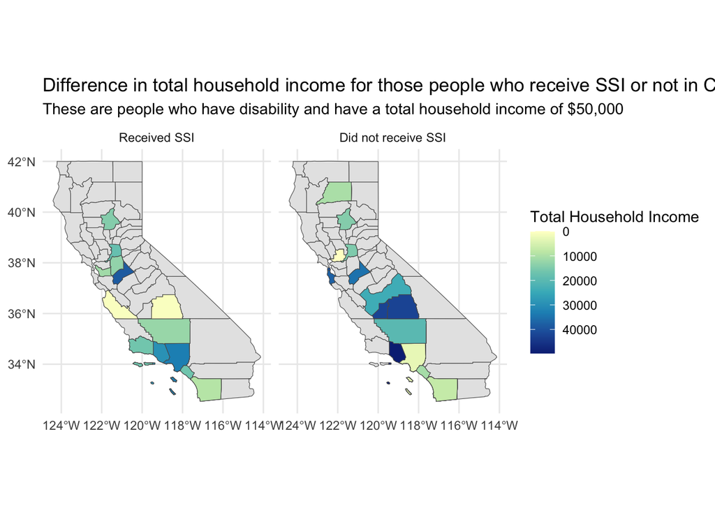

## Summary

The population of both travel map dataset and person house map dataset are assumed to be representative. For both datasets, the proportion of white participants is much more than the proportion of people of color participated. Also, the number of participants without disability is much higher than number of participants with disability. The benefit is that both datasets provide detailed information. The harm is that the majority of participants for both datasets are white people without disability. When we are analyzing people of color or people with disability, both datasets are not representative. Also, both datasets lack data in certain states and counties, so when we are creating maps, there will be a lot of counties/states lack of information.

Through the maps that we have created, policy implications for disabled people which may improve their quality of life, especially when it comes to employment and income, there should be more governmental programs helping those people in the counties in California–particularly those that have the highest population because most disabled people are living there and those that the household income are low and receive SSI–to find jobs and that there should be an established rule or law for the non-discrimination towards people with disabilities when it comes to jobs. In addition, infrastructures and materials such as wheelchair ramps, hearing aids, white canes should be readily available to the counties, or it can be made that the material prices can be lowered. [^2]

[^1]: https://app.perusall.com/courses/sds192-01-introduction-to-data-science-807756242/mp3_data2017_unh_annualreport
[^2]: 10 ways to make society more inclusive for people with disabilities | One Young World. (2023). Oneyoungworld.com